# Análisis de datos de gastos municipales con Pandas y Jupyter Notebooks

# Introducción

Este es el primero de varios talleres introductorios al procesamiento y limpieza de datos. En este estaremos usando como ambiente de trabajo a **Jupyter**, que permite crear documentos con código y prosa, además de almacenar resultados de las operaciones ejecutadas (cálculos, graficas, etc). Jupyter permite interactuar con varios lenguajes de programación, en este, usaremos **Python**, un lenguaje de programación bastante simple y poderoso, con acceso a una gran variedad de librerias para procesamiento de datos. Entre estas, está **Pandas**, una libreria que nos da acceso a estructuras de datos muy poderosas para manipular datos.

¡Comenzemos entonces!

## Instalación

Para poder ejecutar este *Notebook*, necesitas tener instalado Python 3, el cual corre en todos los sistemas operativos actuales, sin embargo, para instalar las dependencias: Pandas y Jupyter.

### Modo Sencillo

Puedes leerte para mas detalles: [https://es.schoolofdata.org/2017/07/20/preparate-para-aprender-python-guia-de-instalacion-de-bibliotecas/)[es.schoolofdata.org/2017/07/20/preparate-para-aprender-python-guia-de-instalacion-de-bibliotecas/]

Recomiendo utilizar la distribución Anaconda https://www.continuum.io/downloads en su version para Python 3, esta incluye instalado Jupyter, Pandas, Numpy y Scipy, y mucho otro software útil. Sigue las instrucciones en la documentacion de Anaconda para configurar un ambiente de desarollo con Jupyter. https://docs.continuum.io/anaconda/navigator/getting-started.html

Una vez instalado, prueba a seguir los paso de https://www.tutorialpython.com/modulos-python/ o tu tutorial de Python Favorito.

### "It's a Unix System, I know This!" - Modo Avanzado

Te recomiendo utilizar Python 3.6 o superior, instalar la version mas reciente posible de virtualenv y pip. Usa Git para obtener el codigo, crea un nuevo entorno de desarollo y ahi instala las dependencias necesarias.

```
~/$ cd notebooks
~/notebooks/$ git clone https://github.com/tian2992/notebooks_dateros.git
~/notebooks/$ cd notebooks_dateros/
~/notebooks/notebooks_dateros/$
~/notebooks/notebooks_dateros/$ virtualenv venv/
~/notebooks/notebooks_dateros/$ source venv/bin/activate
~/notebooks/notebooks_dateros/$ pip install -r requirements.txt
~/notebooks/notebooks_dateros/$ cd 01-Intro
~/notebooks/notebooks_dateros/$ 7z e municipal_guatemala_2008-2011.7z
~/notebooks/notebooks_dateros/$ jupyter-notebook
```

# Primeros pasos

```python
## En Jupyter Notebooks existen varios tipos de celdas, las celdas de código, como esta:
print(1+1)
print(5+4)
6+4
```

```
2
9
```

```
10
```

Y las celdas de texto, que se escriben en Markdown y son hechas para humanos. Pueden incluir **negritas**, *itálicas* Entre otros tipos de estilos. Tambien pueden incluirse imagenes o incluso interactivos. E incluso Mates como en $ \LaTeX $ con ecuaciones y todo... $$ \begin{align} i\hbar\frac{\partial}{\partial t} \Psi(\mathbf{r},\,t) = \hat H \Psi = \left(-\frac{\hbar^2}{2m}\nabla^2 + V(\mathbf{r})\right)\Psi(\mathbf{r},\,t) \end{align} $$

```python
%pylab inline
import seaborn as sns
import pandas as pd
pd.set_option('precision', 5)
```

Con estos comandos, cargamos a nuestro entorno de trabajo las librerias necesarias.

Usemos la funcion de pandas `read_csv` para cargar los datos. Esto crea un `DataFrame`, una unidad de datos en Pandas, que nos da mucha funcionalidad y tiene bastantes propiedades convenientes para el análisis. Probablemente esta operación tome un tiempo asi que sigamos avanzando, cuando esté lista, verás que el numero de la celda habrá sido actualizado.

```python
muni_data = pd.read_csv("municipal_guatemala_2008-2011.zip",
                        sep=";",
                        compression='zip',\
                        error_bad_lines=False)
```

```python
muni_data.head()
```

|  | ANNO | ADMINISTRACIÓN | MUNICIPIO | DEPTO | MUN | FUNC1 | FUNC2 | FUNC3 | ECON1 | ECON2 | ... | ORIGEN2 | ORIGEN3 | PROGRAMA1 | PROGRAMA2 | PROYECTO1 | PROYECTO2 | APROBADO | RETRASADO | EJECUTADO | PAGADO |
| --- | --- | --- | --- | --- | --- | --- | --- | --- | --- | --- | --- | --- | --- | --- | --- | --- | --- | --- | --- | --- | --- |
| 0 | 2008 | Municipal | ALOTENANGO | SACATEPEQUEZ | ALOTENANGO | 1 - ADMINISTRACION GENERAL | 109 - OTRAS ACTIVIDADES DE ADMINISTRACION | Sin Division | 21 Gastos Corrientes | 011 - Personal Permanente | ... | 21 Ingresos Tributarios Iva Paz | No Aplica | No Aplica | No Aplica | No Aplica | No Aplica | Q.- | Q.137,400.00 | Q.137,400.00 | Q.137,400.00 |
| 1 | 2008 | Municipal | ALOTENANGO | SACATEPEQUEZ | ALOTENANGO | 1 - ADMINISTRACION GENERAL | 109 - OTRAS ACTIVIDADES DE ADMINISTRACION | Sin Division | 21 Gastos Corrientes | 011 - Personal Permanente | ... | 21 Ingresos Tributarios Iva Paz | No Aplica | No Aplica | No Aplica | No Aplica | No Aplica | Q.- | Q.- | Q.- | Q.- |
| 2 | 2008 | Municipal | ALOTENANGO | SACATEPEQUEZ | ALOTENANGO | 1 - ADMINISTRACION GENERAL | 109 - OTRAS ACTIVIDADES DE ADMINISTRACION | Sin Division | 21 Gastos Corrientes | 011 - Personal Permanente | ... | 22 Ingresos Ordinarios De Aporte Constitucional | No Aplica | No Aplica | No Aplica | No Aplica | No Aplica | Q.- | Q.- | Q.- | Q.- |
| 3 | 2008 | Municipal | ALOTENANGO | SACATEPEQUEZ | ALOTENANGO | 1 - ADMINISTRACION GENERAL | 109 - OTRAS ACTIVIDADES DE ADMINISTRACION | Sin Division | 21 Gastos Corrientes | 011 - Personal Permanente | ... | 31 Ingresos Propios | No Aplica | No Aplica | No Aplica | No Aplica | No Aplica | Q.240,000.00 | Q.49,588.00 | Q.49,588.00 | Q.49,588.00 |
| 4 | 2008 | Municipal | ALOTENANGO | SACATEPEQUEZ | ALOTENANGO | 1 - ADMINISTRACION GENERAL | 109 - OTRAS ACTIVIDADES DE ADMINISTRACION | Sin Division | 21 Gastos Corrientes | 011 - Personal Permanente | ... | 42 Préstamos Internos | No Aplica | No Aplica | No Aplica | No Aplica | No Aplica | Q.- | Q.- | Q.- | Q.- |

5 rows × 21 columns

## DataFrames y más

Aqui podemos ver el dataframe que creamos. En Pandas, los DataFrames son unidades básicas, junto con las Series.

Veamos una serie muy sencilla antes de pasar a evaluar `muni_data`, el DataFrame que acabamos de crear. Crearemos una serie de numeros aleatorios, y usaremos funciones estadisticas para analizarlo.

```
0   -0.29208
1    0.60887
2   -0.46073
3    0.49752
4   -1.87143
Name: prueba, dtype: float64
count    5.00000
mean    -0.30357
std      0.99465
min     -1.87143
25%     -0.46073
50%     -0.29208
75%      0.49752
max      0.60887
Name: prueba, dtype: float64
```

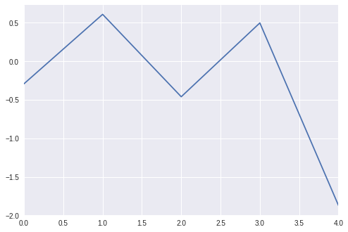

```python
serie_prueba_s = pd.Series(np.random.randn(5), name='prueba')

print(serie_prueba_s)

print(serie_prueba_s.describe())

serie_prueba_s.plot()
```

Con esto podemos ver ya unas propiedades muy interesantes. Las series están basadas en el concepto estadistico, pero incluyen un título (del eje), un índice (el cual identifica a los elementos) y el dato en sí, que puede ser numerico (float), string unicode (texto) u otro tipo de dato.

Las series estan basadas tambien en conceptos de vectores, asi que se pueden realizar operaciones vectoriales en las cuales implicitamente se alinean los indíces, esto es muy util por ejemplo para restar dos columnas, sin importar el tamaño de ambas, automaticamente Pandas unirá inteligentemente ambas series. Puedes tambien obtener elementos de las series por su valor de índice, o por un rango, usando la notación usual en Python. Como nota final, las Series comparten mucho del comportamiento de los NumPy Arrays, haciendolos instantaneamente compatibles con muchas librerias y recursos. https://pandas.pydata.org/pandas-docs/stable/dsintro.html#series

```python
serie_prueba_d = pd.Series(np.random.randn(5), name='prueba 2')

print(serie_prueba_d)

print(serie_prueba_d[0:3]) # Solo los elementos del 0 al 3

# Esto funciona porque ambas series tienen indices en común.
# Si sumamos dos con tamaños distintos, los espacios vacios son marcados como NaN
serie_prueba_y = serie_prueba_d + (serie_prueba_s * 2)
print(serie_prueba_y)
print("La suma de la serie y es: {suma}".format(suma=serie_prueba_y.sum()))
```

```
0    0.10866
1    0.11014
2    0.02647
3   -3.46728
4   -0.12676
Name: prueba 2, dtype: float64
0    0.10866
1    0.11014
2    0.02647
Name: prueba 2, dtype: float64
0   -0.47551
1    1.32789
2   -0.89500
3   -2.47223
4   -3.86963
dtype: float64
La suma de la serie y es: -6.384475154382741
```

Pasemos ahora a DataFrames, como nuestro muni_data DataFrame. Los DataFrames son estructuras bi-dimensionales de datos. Son muy usadas porque proveen una abstracción similar a una hoja de calculo o a una tabla de SQL. Los DataFrame tienen índices (etiquetas de fila) y columnas, ambos ejes deben encajar, y el resto será llenado de datos no validos.

Por ejemplo podemos unir ambas series y crear un DataFrame nuevo, usando un diccionario de Python, por ejemplo. Tambien podemos graficar los resultados.

```
      col1     col2  col3
0 -0.29208  0.10866     1
1  0.60887  0.11014     2
2 -0.46073  0.02647     3
3  0.49752 -3.46728     4
4 -1.87143 -0.12676     0
La suma de cada columna es:
col1    -1.51785
col2    -3.34878
col3    10.00000
dtype: float64
```

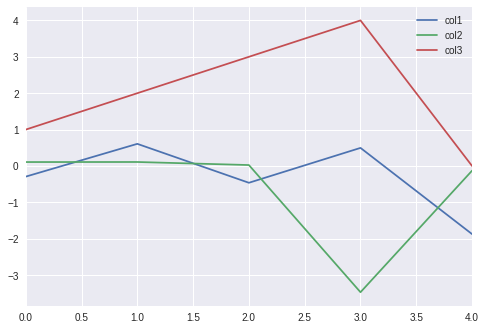

```python
prueba_dict = {
                        "col1": serie_prueba_s,
                        "col2": serie_prueba_d,
                        "col3": [1, 2, 3, 4, 0]
             }
prueba_data_frame = pd.DataFrame(prueba_dict)
print(prueba_data_frame)
# La operacion .sum() ahora retorna un DataFrame, pero Pandas sabe no combinar peras con manzanas.
print("La suma de cada columna es: \n{suma}".format(suma=prueba_data_frame.sum()))
prueba_data_frame.plot()
```

Veamos ahora ya, nuestro DataFrame creado con los datos, muni_data.

```python
#muni_data
```

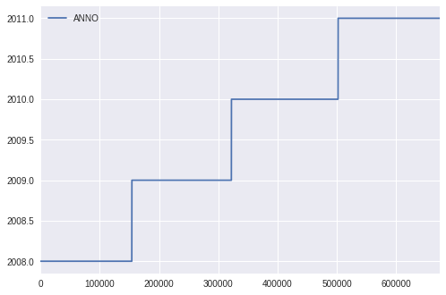

```python
# Una grafica bastante inutil, ¿porque?

muni_data.plot()
```

```python
# Veamos los datos, limitamos a solo los primeros 5 filas.

muni_data.head(5)
```

|  | ANNO | ADMINISTRACIÓN | MUNICIPIO | DEPTO | MUN | FUNC1 | FUNC2 | FUNC3 | ECON1 | ECON2 | ... | ORIGEN2 | ORIGEN3 | PROGRAMA1 | PROGRAMA2 | PROYECTO1 | PROYECTO2 | APROBADO | RETRASADO | EJECUTADO | PAGADO |
| --- | --- | --- | --- | --- | --- | --- | --- | --- | --- | --- | --- | --- | --- | --- | --- | --- | --- | --- | --- | --- | --- |
| 0 | 2008 | Municipal | ALOTENANGO | SACATEPEQUEZ | ALOTENANGO | 1 - ADMINISTRACION GENERAL | 109 - OTRAS ACTIVIDADES DE ADMINISTRACION | Sin Division | 21 Gastos Corrientes | 011 - Personal Permanente | ... | 21 Ingresos Tributarios Iva Paz | No Aplica | No Aplica | No Aplica | No Aplica | No Aplica | Q.- | Q.137,400.00 | Q.137,400.00 | Q.137,400.00 |
| 1 | 2008 | Municipal | ALOTENANGO | SACATEPEQUEZ | ALOTENANGO | 1 - ADMINISTRACION GENERAL | 109 - OTRAS ACTIVIDADES DE ADMINISTRACION | Sin Division | 21 Gastos Corrientes | 011 - Personal Permanente | ... | 21 Ingresos Tributarios Iva Paz | No Aplica | No Aplica | No Aplica | No Aplica | No Aplica | Q.- | Q.- | Q.- | Q.- |
| 2 | 2008 | Municipal | ALOTENANGO | SACATEPEQUEZ | ALOTENANGO | 1 - ADMINISTRACION GENERAL | 109 - OTRAS ACTIVIDADES DE ADMINISTRACION | Sin Division | 21 Gastos Corrientes | 011 - Personal Permanente | ... | 22 Ingresos Ordinarios De Aporte Constitucional | No Aplica | No Aplica | No Aplica | No Aplica | No Aplica | Q.- | Q.- | Q.- | Q.- |
| 3 | 2008 | Municipal | ALOTENANGO | SACATEPEQUEZ | ALOTENANGO | 1 - ADMINISTRACION GENERAL | 109 - OTRAS ACTIVIDADES DE ADMINISTRACION | Sin Division | 21 Gastos Corrientes | 011 - Personal Permanente | ... | 31 Ingresos Propios | No Aplica | No Aplica | No Aplica | No Aplica | No Aplica | Q.240,000.00 | Q.49,588.00 | Q.49,588.00 | Q.49,588.00 |
| 4 | 2008 | Municipal | ALOTENANGO | SACATEPEQUEZ | ALOTENANGO | 1 - ADMINISTRACION GENERAL | 109 - OTRAS ACTIVIDADES DE ADMINISTRACION | Sin Division | 21 Gastos Corrientes | 011 - Personal Permanente | ... | 42 Préstamos Internos | No Aplica | No Aplica | No Aplica | No Aplica | No Aplica | Q.- | Q.- | Q.- | Q.- |

5 rows × 21 columns

```python
## La columna 'APROBADO' se ve un poco sospechosa.
## Python toma a los numeros como números, no con una Q ni un punto (si no lo tiene) ni comas innecesarias.
## Veamos mas a detalle.

muni_data['APROBADO'].head()
```

```
0            Q.-
1            Q.-
2            Q.-
3     Q.240,000.00
4            Q.-
Name: APROBADO, dtype: object
```

```python
# Vamos a ignorar esto por un momento, pero los números de verdad son de tipo float
```

Veamos cuantas columnas son, podemos explorar un poco mas asi.

```python
muni_data.columns
```

```
Index(['ANNO', 'ADMINISTRACIÓN', 'MUNICIPIO', 'DEPTO', 'MUN', 'FUNC1', 'FUNC2',
       'FUNC3', 'ECON1', 'ECON2', 'ORIGEN1', 'ORIGEN2', 'ORIGEN3', 'PROGRAMA1',
       'PROGRAMA2', 'PROYECTO1', 'PROYECTO2', 'APROBADO', 'RETRASADO',
       'EJECUTADO', 'PAGADO'],
      dtype='object')
```

```python
muni_data['MUNICIPIO'].unique()[:5] # Listame 5 municipios
```

```
array(['ALOTENANGO', 'AMATITLAN', 'ATESCATEMPA', 'AYUTLA', 'CABAÑAS'], dtype=object)
```

```python
print("Funcion 1: \n {func1} \n Funcion 2: \n {func2} \n Funcion 3: \n{func3}".format(
        func1=muni_data["FUNC1"].unique(),
        func2=muni_data["FUNC2"].unique(),
        func3=muni_data["FUNC3"].unique()
        )
     )
```

```
Funcion 1:
 ['1 - ADMINISTRACION GENERAL' '3 - SERVICIOS SOCIALES'
 '2 - DEFENSA Y SEGURIDAD INTERNA' 'Sin Finalidad'
 '4 - SERVICIOS ECONOMICOS' '5 - DEUDA PUBLICA'
 '6 - OTROS NO CLASIFICABLES' '01 - SERVICIOS PUBLICOS GENERALES'
 '08 - SALUD' '07 - URBANIZACION Y SERVICIOS COMUNITARIOS'
 '05 - ASUNTOS ECONOMICOS' '06 - PROTECCION AMBIENTAL' '10 - EDUCACION'
 '12 - TRANSACCIONES DE LA DEUDA PUBLICA'
 '03 - ORDEN PUBLICO Y SEGURIDAD CIUDADANA'
 '09 - ACTIVIDADES DEPORTIVAS, RECREATIVAS, CULTURA Y RELIGION'
 '11 - PROTECCION SOCIAL' '04 - ATENCION A DESASTRES Y GESTION DE RIESGOS'
 '02 - DEFENSA']
 Funcion 2:
 ['109 - OTRAS ACTIVIDADES DE ADMINISTRACION' '306-AGUA Y SANEAMIENTO'
 '309-MEDIO AMBIENTE' '303-EDUCACION' '202-SEGURIDAD INTERNA'
 '304-CULTURA Y DEPORTES' '301-SALUD Y ASISTENCIA SOCIAL' 'Sin Funcion'
 '404-TRANSPORTE' '405-INDUSTRIA  Y  COMERCIO'
 '409-OTRAS ACTIVIDADES DE SERVICIOS ECONOMICOS'
 '106-ADMINISTRACION FISCAL' '406-TURISMO'
 '310-OTRAS ACTIVIDADES DE SERVICIOS SOCIALES' '402-ENERGIA'
 '403-COMUNICACIONES' '302-TRABAJO Y PREVISION SOCIAL'
 '107-AUDITORIA Y CONTROL' '501-INTERESES, COMISIONES Y OTROS GASTOS'
 '201-DEFENSA' '601-AMORTIZACION DE DEUDA' '407-AGROPECUARIO'
 '101-LEGISLATIVA' '307-VIVIENDA' '308-DESARROLLO URBANO Y RURAL'
 '401-MINERIA E HIDROCARBUROS' '408-FINANCIERAS Y SEGUROS'
 '602-DISMINUCION DE OTROS PASIVOS' '603-OTROS GASTOS'
 '103-DIRECCION GUBERNAMENTAL' '108-SERVICIOS GENERALES'
 '104-RELACIONES INTERIORES' '102-JUDICIAL' '305-CIENCIA Y TECNOLOGIA'
 '105-RELACIONES EXTERIORES'
 '0101 - Administracion legislative, ejecutiva y asuntos exteriores'
 '0803 - Servicios hospitalarios' '0703 - Abastecimiento de agua'
 '0502 - Agricultura, produccion pecuaria, silvicultura, caza y pesca'
 '0505 - Transporte' '0602 - Ordenación de aguas residuales'
 '0702 - Desarrollo comunitario' '1002 - Educación media'
 '1001 - Educación preprimaria y primaria'
 '0805 - Investigación y desarrollo relacionados con la Salud'
 '0503 - Combustibles y energia'
 '1201 - Intereses y comisiones de la deuda pública'
 '1202 - Amortizaciones de deuda pública'
 '0102 - Administracion fiscal, monetaria y servicios de fiscalizacion'
```

[output cut: 122 more lines]

```
 '080304-Servicios de salud y residencias a personas de la tercera edad y residencias de convalecencia'
 '050702-Hoteles y restaurantes' '050703-Turismo'
 '050801-Investigación y desarrollo relacionados con asuntos económicos, comerciales y laborales en general'
 '030302-Defensoría de los derechos humanos' '110501-Desempleo'
 '050805-Investigación y desarrollo relacionados con el transporte'
 '050803-Investigación y desarrollo relacionados con combustibles y energía'
 '110102-Funcionamiento corporal y discapacidad'
 '050706-Seguros y fianzas' '050504-Transporte aéreo'
 '030601-Investigación y desarrollo relacionados con el orden público y seguridad ciudadana'
 '050503-Transporte por ferrocarril'
 '030401-Administración de asuntos penitenciarios'
 '100602-Servicios auxiliares de la educación media'
 '100604-Servicios auxiliares de la educación universitaria o superior'
 '010302-Ayuda económica prestada a través de organismos internacionales'
 '050802-Investigación y desarrollo relacionados con agricultura, producción pecuaria, silvicultura, caza y p']
```

Vamos a explorar un poco con indices y etiquetas:

```python
index_geo_data = muni_data.set_index("DEPTO","MUNICIPIO").sort_index()
```

```python
index_geo_data.loc[
                    ["GUATEMALA","ESCUINTLA","SACATEPEQUEZ"],
                    ['FUNC1','FUNC2','FUNC3','APROBADO','EJECUTADO']
                  ].head()
```

| DEPTO | FUNC1 | FUNC2 | FUNC3 | APROBADO | EJECUTADO |
| --- | --- | --- | --- | --- | --- |
| GUATEMALA | 01 - SERVICIOS PUBLICOS GENERALES | 0101 - Administracion legislative, ejecutiva y... | 010102-Ejecutiva | Q.34,180.00 | NaN |
| GUATEMALA | 01 - SERVICIOS PUBLICOS GENERALES | 0101 - Administracion legislative, ejecutiva y... | 010102-Ejecutiva | Q.42,000.00 | NaN |
| GUATEMALA | 01 - SERVICIOS PUBLICOS GENERALES | 0101 - Administracion legislative, ejecutiva y... | 010102-Ejecutiva | Q.42,000.00 | NaN |
| GUATEMALA | 01 - SERVICIOS PUBLICOS GENERALES | 0101 - Administracion legislative, ejecutiva y... | 010102-Ejecutiva | Q.320,000.00 | NaN |
| GUATEMALA | 01 - SERVICIOS PUBLICOS GENERALES | 0101 - Administracion legislative, ejecutiva y... | 010102-Ejecutiva | Q.1,000.00 | NaN |

Ahora que podemos realizar selección basica, pensamos, que podemos hacer con estos datos, y nos enfrentamos a un problema...

```python
muni_data['APROBADO'][3] * 2
```

```
' Q.240,000.00  Q.240,000.00 '
```

*¡Rayos!* porque no puedo manipular estos datos así como los otros, y es porque son de tipo texto y no números.

```python
# muni_data['APROBADO'].sum() ## No correr, falla...
```

Necesitamos crear una funcion para limpiar estos tipos de dato que son texto, para poderlos convertir a numeros de tipo punto flotante (decimales).

```python
## Esto es una funcion en Python, con def definimos el nombre de esta funcion, 'clean_q'
## esta recibe un objeto de entrada.

def clean_q(input_object):
    from re import sub  ## importamos la función sub, que substituye utilizando patrones
    ## https://es.wikipedia.org/wiki/Expresión_regular

    ## NaN es un objeto especial que representa un valor numérico invalido, Not A Number.
    if input_object == NaN:
        return 0
    inp = unicode(input_object) # De objeto a un texto
    cleansed_q = sub(r'Q\.','', inp) # Remueve Q., el slash evita que . sea interpretado como un caracter especial
    cleansed_00 = sub(r'\.00', '', cleansed_q) # Igual aqui
    cleansed_comma = sub(',', '', cleansed_00)
    cleansed_dash = sub('-', '', cleansed_comma)
    cleansed_nonchar = sub(r'[^0-9]+', '', cleansed_dash)
    if cleansed_nonchar == '':
        return 0
    return cleansed_nonchar
```

```python
presupuesto_aprobado = muni_data['APROBADO'].map(clean_q).astype(float)
```

```python
presupuesto_aprobado.describe()
```

```
count    6.74135e+05
mean     3.64625e+05
std      8.43016e+06
min      0.00000e+00
25%      0.00000e+00
50%      1.00000e+03
75%      1.50000e+04
max      1.43719e+09
Name: APROBADO, dtype: float64
```

```python
muni_data['EJECUTADO'].head()
```

```
0     Q.137,400.00
1            Q.-
2            Q.-
3      Q.49,588.00
4            Q.-
Name: EJECUTADO, dtype: object
```

```python
muni_data['FUNC1'].str.upper().value_counts()
```

```
1 - ADMINISTRACION GENERAL                                      150541
01 - SERVICIOS PUBLICOS GENERALES                               107911
SIN FINALIDAD                                                   100862
3 - SERVICIOS SOCIALES                                           96451
4 - SERVICIOS ECONOMICOS                                         65763
07 - URBANIZACION Y SERVICIOS COMUNITARIOS                       40349
05 - ASUNTOS ECONOMICOS                                          38126
10 - EDUCACION                                                   18584
06 - PROTECCION AMBIENTAL                                        17359
09 - ACTIVIDADES DEPORTIVAS, RECREATIVAS, CULTURA Y RELIGION     11929
03 - ORDEN PUBLICO Y SEGURIDAD CIUDADANA                          7137
08 - SALUD                                                        5707
12 - TRANSACCIONES DE LA DEUDA PUBLICA                            3470
11 - PROTECCION SOCIAL                                            3338
6 - OTROS NO CLASIFICABLES                                        2565
2 - DEFENSA Y SEGURIDAD INTERNA                                   1662
04 - ATENCION A DESASTRES Y GESTION DE RIESGOS                    1179
5 - DEUDA PUBLICA                                                 1073
02 - DEFENSA                                                       129
Name: FUNC1, dtype: int64
```

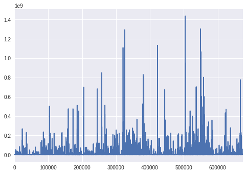

```python
presupuesto_aprobado.plot()
```

Bueno, ahora ya tenemos estas series de datos convertidas. ¿como las volvemos a agregar al dataset? ¡Facil! lo volvemos a insertar al DataFrame original, sobreescribiendo esa columna.

```python
for col in ('APROBADO', 'RETRASADO', 'EJECUTADO', 'PAGADO'):
    muni_data[col] = muni_data[col].map(clean_q).astype(float)
```

```python
muni_data['APROBADO'].sum()
```

```
245806713741.0
```

```python
muni_data.head()
```

|  | ANNO | ADMINISTRACIÓN | MUNICIPIO | DEPTO | MUN | FUNC1 | FUNC2 | FUNC3 | ECON1 | ECON2 | ... | ORIGEN2 | ORIGEN3 | PROGRAMA1 | PROGRAMA2 | PROYECTO1 | PROYECTO2 | APROBADO | RETRASADO | EJECUTADO | PAGADO |
| --- | --- | --- | --- | --- | --- | --- | --- | --- | --- | --- | --- | --- | --- | --- | --- | --- | --- | --- | --- | --- | --- |
| 0 | 2008 | Municipal | ALOTENANGO | SACATEPEQUEZ | ALOTENANGO | 1 - ADMINISTRACION GENERAL | 109 - OTRAS ACTIVIDADES DE ADMINISTRACION | Sin Division | 21 Gastos Corrientes | 011 - Personal Permanente | ... | 21 Ingresos Tributarios Iva Paz | No Aplica | No Aplica | No Aplica | No Aplica | No Aplica | 0.0 | 137400.0 | 137400.0 | 137400.0 |
| 1 | 2008 | Municipal | ALOTENANGO | SACATEPEQUEZ | ALOTENANGO | 1 - ADMINISTRACION GENERAL | 109 - OTRAS ACTIVIDADES DE ADMINISTRACION | Sin Division | 21 Gastos Corrientes | 011 - Personal Permanente | ... | 21 Ingresos Tributarios Iva Paz | No Aplica | No Aplica | No Aplica | No Aplica | No Aplica | 0.0 | 0.0 | 0.0 | 0.0 |
| 2 | 2008 | Municipal | ALOTENANGO | SACATEPEQUEZ | ALOTENANGO | 1 - ADMINISTRACION GENERAL | 109 - OTRAS ACTIVIDADES DE ADMINISTRACION | Sin Division | 21 Gastos Corrientes | 011 - Personal Permanente | ... | 22 Ingresos Ordinarios De Aporte Constitucional | No Aplica | No Aplica | No Aplica | No Aplica | No Aplica | 0.0 | 0.0 | 0.0 | 0.0 |
| 3 | 2008 | Municipal | ALOTENANGO | SACATEPEQUEZ | ALOTENANGO | 1 - ADMINISTRACION GENERAL | 109 - OTRAS ACTIVIDADES DE ADMINISTRACION | Sin Division | 21 Gastos Corrientes | 011 - Personal Permanente | ... | 31 Ingresos Propios | No Aplica | No Aplica | No Aplica | No Aplica | No Aplica | 240000.0 | 49588.0 | 49588.0 | 49588.0 |
| 4 | 2008 | Municipal | ALOTENANGO | SACATEPEQUEZ | ALOTENANGO | 1 - ADMINISTRACION GENERAL | 109 - OTRAS ACTIVIDADES DE ADMINISTRACION | Sin Division | 21 Gastos Corrientes | 011 - Personal Permanente | ... | 42 Préstamos Internos | No Aplica | No Aplica | No Aplica | No Aplica | No Aplica | 0.0 | 0.0 | 0.0 | 0.0 |

5 rows × 21 columns

```python
muni_data['ECON1'].unique()
```

```
array(['21 Gastos Corrientes', '22 Gastos de Capital',
       '23 Aplicaciones Financieras'], dtype=object)
```

Ahora si, ¡ya podemos agrupar y hacer indices bien!

```python
index_geo_data = muni_data.set_index("DEPTO","MUNICIPIO").sort_index()
```

```python
index_geo_data.head(4)
```

[output not shown]

```python
mi_muni_d = muni_data.set_index(["ANNO"],["DEPTO","MUNICIPIO"],["FUNC1","ECON1","ORIGEN1"]).sort_index()
```

```python
mi_muni_d.head()
```

[output not shown]

```python
## Para obtener mas ayuda, ejecuta:
# help(mi_muni_d)
```

```python
mi_muni_d.columns
```

```
Index(['ADMINISTRACIÓN', 'MUNICIPIO', 'DEPTO', 'MUN', 'FUNC1', 'FUNC2',
       'FUNC3', 'ECON1', 'ECON2', 'ORIGEN1', 'ORIGEN2', 'ORIGEN3', 'PROGRAMA1',
       'PROGRAMA2', 'PROYECTO1', 'PROYECTO2', 'APROBADO', 'RETRASADO',
       'EJECUTADO', 'PAGADO'],
      dtype='object')
```

```python
mi_muni_d["DEPTO"].describe()
```

```
count        674135
unique           22
top       GUATEMALA
freq          55520
Name: DEPTO, dtype: object
```

```python
year_grouped = mi_muni_d.groupby("ANNO").sum()
```

```python
year_grouped
```

| ANNO | APROBADO | RETRASADO | EJECUTADO | PAGADO |
| --- | --- | --- | --- | --- |
| 2008 | 2.68353e+10 | 2.45634e+11 | 4.14921e+11 | 4.12270e+11 |
| 2009 | 5.31561e+10 | 2.99390e+11 | 4.81259e+11 | 4.77409e+11 |
| 2010 | 7.32193e+10 | 3.28068e+11 | 0.00000e+00 | 5.26614e+11 |
| 2011 | 9.25959e+10 | 3.39514e+11 | 0.00000e+00 | 5.42302e+11 |

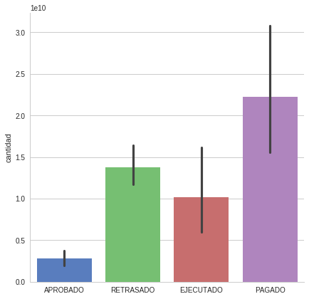

```python
year_dep_grouped = mi_muni_d.groupby(["ANNO","DEPTO"]).sum()
year_dep_grouped.head()

sns.set(style="whitegrid")

# Draw a nested barplot to show survival for class and sex
g = sns.factorplot( data=year_dep_grouped,
                   size=6, kind="bar", palette="muted")
# g.despine(left=True)
g.set_ylabels("cantidad")
```

```python
year_dep_grouped.head()
```

| ANNO | DEPTO | APROBADO | RETRASADO | EJECUTADO | PAGADO |
| --- | --- | --- | --- | --- | --- |
| 2008 | ALTA VERAPAZ | 2.78291e+09 | 1.46371e+10 | 1.63018e+10 | 1.61846e+10 |
|  | BAJA VERAPAZ | 6.13609e+08 | 6.77458e+09 | 6.57817e+09 | 6.56299e+09 |
|  | CHIMALTENANGO | 9.42927e+08 | 8.63124e+09 | 1.30331e+10 | 1.30252e+10 |
|  | CHIQUIMULA | 5.74758e+08 | 7.30016e+09 | 7.62139e+09 | 7.59232e+09 |
|  | EL PROGRESO | 3.53643e+08 | 5.29144e+09 | 7.06977e+09 | 7.03881e+09 |

## Contestando preguntas

Ahora ya podemos contestar algunas clases de preguntas agrupando estas entradas individuales de de datos. ¿Que tal el departamento que tiene mas gasto en Seguridad? ¿Los tipos de gasto mas elevados como suelen ser pagados?

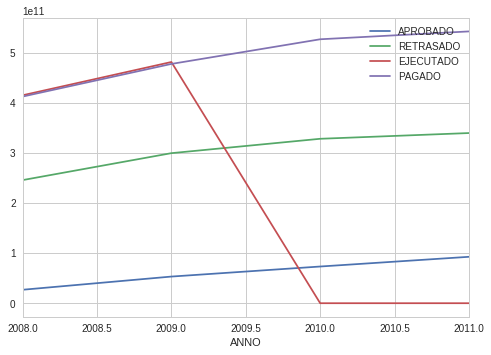

```python
year_grouped.plot()
```

```python
year_dep_group = mi_muni_d.groupby(["DEPTO","ANNO"]).sum()
```

```python
year_dep_group.unstack().head()
```

| ANNO DEPTO | APROBADO 2008 | APROBADO 2009 | APROBADO 2010 | APROBADO 2011 | RETRASADO 2008 | RETRASADO 2009 | RETRASADO 2010 | RETRASADO 2011 | EJECUTADO 2008 | EJECUTADO 2009 | EJECUTADO 2010 | EJECUTADO 2011 | PAGADO 2008 | PAGADO 2009 | PAGADO 2010 | PAGADO 2011 |
| --- | --- | --- | --- | --- | --- | --- | --- | --- | --- | --- | --- | --- | --- | --- | --- | --- |
| ALTA VERAPAZ | 2.78291e+09 | 5.64744e+09 | 1.95357e+10 | 2.12952e+10 | 1.46371e+10 | 2.09176e+10 | 3.22332e+10 | 3.77961e+10 | 1.63018e+10 | 2.18337e+10 | 0.0 | 0.0 | 1.61846e+10 | 2.15977e+10 | 2.06492e+10 | 2.38565e+10 |
| BAJA VERAPAZ | 6.13609e+08 | 1.93412e+09 | 1.55609e+09 | 3.10721e+09 | 6.77458e+09 | 7.40240e+09 | 9.37046e+09 | 1.15378e+10 | 6.57817e+09 | 7.00557e+09 | 0.0 | 0.0 | 6.56299e+09 | 6.97541e+09 | 8.10811e+09 | 1.04986e+10 |
| CHIMALTENANGO | 9.42927e+08 | 2.36969e+09 | 2.95906e+09 | 2.63505e+09 | 8.63124e+09 | 9.65804e+09 | 9.83285e+09 | 8.07592e+09 | 1.30331e+10 | 1.19265e+10 | 0.0 | 0.0 | 1.30252e+10 | 1.17757e+10 | 1.27430e+10 | 1.25867e+10 |
| CHIQUIMULA | 5.74758e+08 | 7.94670e+08 | 2.40722e+09 | 3.12491e+09 | 7.30016e+09 | 7.01026e+09 | 9.74311e+09 | 8.95407e+09 | 7.62139e+09 | 7.77514e+09 | 0.0 | 0.0 | 7.59232e+09 | 7.68196e+09 | 9.47250e+09 | 9.48921e+09 |
| EL PROGRESO | 3.53643e+08 | 9.42015e+08 | 1.98337e+09 | 2.09171e+09 | 5.29144e+09 | 6.41684e+09 | 6.02155e+09 | 6.51524e+09 | 7.06977e+09 | 7.01621e+09 | 0.0 | 0.0 | 7.03881e+09 | 6.94013e+09 | 8.77785e+09 | 8.27554e+09 |

```python
func_p = mi_muni_d.groupby(["FUNC1"]).sum()
func_dep = mi_muni_d.groupby(["FUNC1","DEPTO"]).sum()
func_p
```

| FUNC1 | APROBADO | RETRASADO | EJECUTADO | PAGADO |
| --- | --- | --- | --- | --- |
| 01 - SERVICIOS PUBLICOS GENERALES | 2.12896e+10 | 9.39864e+10 | 0.00000e+00 | 1.46451e+11 |
| 02 - DEFENSA | 7.65149e+06 | 4.85768e+07 | 0.00000e+00 | 1.15252e+08 |
| 03 - ORDEN PUBLICO Y SEGURIDAD CIUDADANA | 1.54112e+09 | 4.62692e+09 | 0.00000e+00 | 9.71618e+09 |
| 04 - ATENCION A DESASTRES Y GESTION DE RIESGOS | 2.02693e+08 | 1.46343e+09 | 0.00000e+00 | 1.90633e+09 |
| 05 - ASUNTOS ECONOMICOS | 3.53597e+10 | 1.16573e+11 | 0.00000e+00 | 1.08795e+11 |
| 06 - PROTECCION AMBIENTAL | 6.82913e+09 | 2.43591e+10 | 0.00000e+00 | 3.15289e+10 |
| 07 - URBANIZACION Y SERVICIOS COMUNITARIOS | 2.35510e+10 | 9.90229e+10 | 0.00000e+00 | 1.12771e+11 |
| 08 - SALUD | 1.79933e+09 | 6.12886e+09 | 0.00000e+00 | 7.90331e+09 |
| 09 - ACTIVIDADES DEPORTIVAS, RECREATIVAS, CULTURA Y RELIGION | 2.02757e+09 | 1.08670e+10 | 0.00000e+00 | 1.33765e+10 |
| 1 - ADMINISTRACION GENERAL | 2.22609e+10 | 1.53756e+11 | 2.87329e+11 | 2.86671e+11 |
| 10 - EDUCACION | 7.38670e+09 | 2.92963e+10 | 0.00000e+00 | 3.05241e+10 |
| 11 - PROTECCION SOCIAL | 6.06386e+08 | 7.10021e+09 | 0.00000e+00 | 1.26944e+10 |
| 12 - TRANSACCIONES DE LA DEUDA PUBLICA | 1.94713e+10 | 6.97031e+10 | 0.00000e+00 | 8.69565e+10 |
| 2 - DEFENSA Y SEGURIDAD INTERNA | 2.69279e+08 | 1.41168e+09 | 1.11557e+10 | 1.11701e+10 |
| 3 - SERVICIOS SOCIALES | 2.46567e+10 | 1.48437e+11 | 2.16065e+11 | 2.13887e+11 |
| 4 - SERVICIOS ECONOMICOS | 2.27707e+10 | 1.67108e+11 | 2.47066e+11 | 2.43517e+11 |
| 5 - DEUDA PUBLICA | 2.54276e+09 | 1.80157e+10 | 2.89121e+10 | 2.89121e+10 |
| 6 - OTROS NO CLASIFICABLES | 6.22515e+09 | 4.34632e+10 | 9.32827e+10 | 9.31423e+10 |
| Sin Finalidad | 4.70091e+10 | 2.17238e+11 | 1.23702e+10 | 5.18558e+11 |

```python
func_dep_flat = func_dep.unstack()
```

```python
func_dep_flat.head()
```

| DEPTO FUNC1 | APROBADO ALTA VERAPAZ | APROBADO BAJA VERAPAZ | APROBADO CHIMALTENANGO | APROBADO CHIQUIMULA | APROBADO EL PROGRESO | APROBADO ESCUINTLA | APROBADO GUATEMALA | APROBADO HUEHUETENANGO | APROBADO IZABAL | APROBADO JALAPA | ... | PAGADO QUETZALTENANGO | PAGADO QUICHE | PAGADO RETALHULEU | PAGADO SACATEPEQUEZ | PAGADO SAN MARCOS | PAGADO SANTA ROSA | PAGADO SOLOLA | PAGADO SUCHITEPEQUEZ | PAGADO TOTONICAPAN | PAGADO ZACAPA |
| --- | --- | --- | --- | --- | --- | --- | --- | --- | --- | --- | --- | --- | --- | --- | --- | --- | --- | --- | --- | --- | --- |
| 01 - SERVICIOS PUBLICOS GENERALES | 2.65028e+09 | 5.44695e+08 | 6.02520e+08 | 1.45687e+09 | 5.06434e+08 | 1.82266e+09 | 4.99280e+09 | 1.26883e+09 | 1.95440e+08 | 4.06992e+08 | ... | 5.56908e+09 | 3.55170e+09 | 3.88756e+09 | 1.42191e+10 | 6.86290e+09 | 5.26960e+09 | 5.25078e+09 | 3.65925e+09 | 1.48548e+09 | 7.83247e+09 |
| 02 - DEFENSA | 0.00000e+00 | 4.18211e+06 | NaN | 1.25551e+06 | NaN | 8.25311e+05 | 0.00000e+00 | NaN | NaN | 5.80000e+05 | ... | 6.50000e+01 | 4.45000e+04 | NaN | NaN | NaN | 2.81500e+04 | NaN | NaN | NaN | 0.00000e+00 |
| 03 - ORDEN PUBLICO Y SEGURIDAD CIUDADANA | 4.15592e+08 | 2.73807e+06 | 1.73070e+07 | 1.20563e+08 | 3.46200e+05 | 8.40011e+06 | 7.54022e+07 | 8.85087e+07 | 1.34582e+06 | 4.66579e+07 | ... | 1.11593e+09 | 9.09038e+07 | 3.09004e+08 | 2.05695e+09 | 2.18261e+07 | 1.47161e+07 | 2.27009e+08 | 8.04501e+08 | 3.30255e+07 | 5.84190e+08 |
| 04 - ATENCION A DESASTRES Y GESTION DE RIESGOS | 1.65910e+06 | 1.21105e+06 | 1.55504e+06 | 1.00000e+05 | 0.00000e+00 | 1.09773e+08 | 1.60380e+07 | 7.50000e+04 | 8.19824e+05 | 1.25000e+05 | ... | 3.74758e+06 | 1.42707e+07 | 2.55000e+04 | 1.97266e+08 | 8.83148e+07 | 1.64157e+05 | 2.05584e+08 | 1.63782e+08 | 2.30420e+07 | 3.34638e+08 |
| 05 - ASUNTOS ECONOMICOS | 2.18998e+10 | 9.96920e+08 | 8.61639e+08 | 5.23307e+08 | 7.35246e+07 | 1.12597e+09 | 6.27814e+08 | 3.92554e+09 | 4.30563e+08 | 9.99355e+07 | ... | 9.02544e+09 | 5.93387e+09 | 3.12895e+09 | 5.35538e+09 | 5.26815e+09 | 1.59234e+09 | 4.55446e+09 | 2.28815e+09 | 1.23100e+09 | 1.34795e+09 |

5 rows × 88 columns

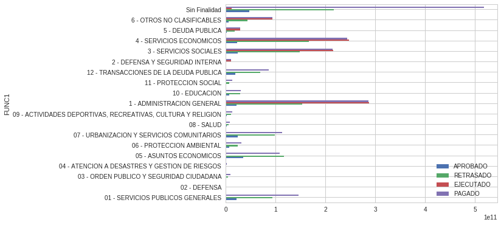

```python
func_p.plot(kind="barh", figsize=(8,6), linewidth=2.5)
```

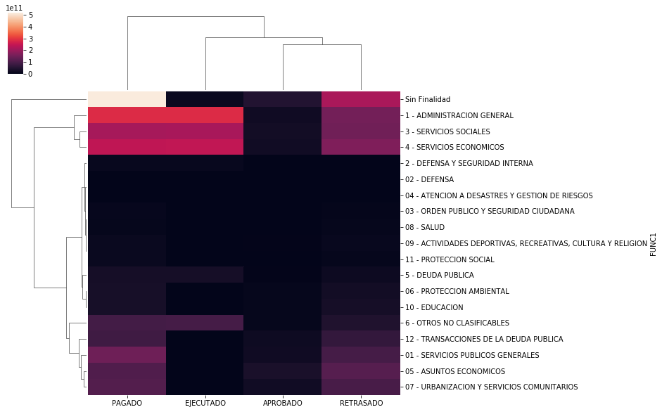

```python
g = sns.clustermap(func_p)
```